# Risk Factor Analysis

## Outcome Variable

**Outcome Variable:** ever_wasted

## Predictor Variables

**Intervention Variable:** predfeed36

**Adjustment Set:**

- arm
- sex
- month
- brthmon
- W_mage
- meducyrs
- feducyrs
- hhwealth_quart
- hfoodsec
- W_mhtcm
- vagbrth
- W_gagebrth
- W_birthwt
- W_birthlen
- W_nrooms
- W_nchldlt5
- W_parity
- impfloor
- impsan
- safeh20
- delta_W_mage
- delta_meducyrs
- delta_feducyrs
- delta_hhwealth_quart
- delta_hfoodsec
- delta_W_mhtcm
- delta_vagbrth
- delta_W_gagebrth
- delta_W_birthwt
- delta_W_birthlen
- delta_W_nrooms
- delta_W_nchldlt5
- delta_W_parity
- delta_impfloor
- delta_impsan
- delta_safeh20

## Stratifying Variables

The analysis was stratified on these variable(s):

- agecat
- studyid
- country

## Data Summary

| agecat | studyid | country | predfeed36 | ever_wasted | n_cell | n |
| --- | --- | --- | --- | --- | --- | --- |
| 0-24 months (no birth wast) | ki0047075b-MAL-ED | BANGLADESH | 1 | 0 | 96 | 251 |
| 0-24 months (no birth wast) | ki0047075b-MAL-ED | BANGLADESH | 1 | 1 | 35 | 251 |
| 0-24 months (no birth wast) | ki0047075b-MAL-ED | BANGLADESH | 0 | 0 | 98 | 251 |
| 0-24 months (no birth wast) | ki0047075b-MAL-ED | BANGLADESH | 0 | 1 | 22 | 251 |
| 0-24 months (no birth wast) | ki0047075b-MAL-ED | BRAZIL | 1 | 0 | 37 | 224 |
| 0-24 months (no birth wast) | ki0047075b-MAL-ED | BRAZIL | 1 | 1 | 0 | 224 |
| 0-24 months (no birth wast) | ki0047075b-MAL-ED | BRAZIL | 0 | 0 | 175 | 224 |
| 0-24 months (no birth wast) | ki0047075b-MAL-ED | BRAZIL | 0 | 1 | 12 | 224 |
| 0-24 months (no birth wast) | ki0047075b-MAL-ED | INDIA | 1 | 0 | 15 | 238 |
| 0-24 months (no birth wast) | ki0047075b-MAL-ED | INDIA | 1 | 1 | 5 | 238 |
| 0-24 months (no birth wast) | ki0047075b-MAL-ED | INDIA | 0 | 0 | 135 | 238 |
| 0-24 months (no birth wast) | ki0047075b-MAL-ED | INDIA | 0 | 1 | 83 | 238 |
| 0-24 months (no birth wast) | ki0047075b-MAL-ED | NEPAL | 1 | 0 | 28 | 237 |
| 0-24 months (no birth wast) | ki0047075b-MAL-ED | NEPAL | 1 | 1 | 4 | 237 |
| 0-24 months (no birth wast) | ki0047075b-MAL-ED | NEPAL | 0 | 0 | 164 | 237 |
| 0-24 months (no birth wast) | ki0047075b-MAL-ED | NEPAL | 0 | 1 | 41 | 237 |
| 0-24 months (no birth wast) | ki0047075b-MAL-ED | PERU | 1 | 0 | 123 | 287 |
| 0-24 months (no birth wast) | ki0047075b-MAL-ED | PERU | 1 | 1 | 4 | 287 |
| 0-24 months (no birth wast) | ki0047075b-MAL-ED | PERU | 0 | 0 | 145 | 287 |
| 0-24 months (no birth wast) | ki0047075b-MAL-ED | PERU | 0 | 1 | 15 | 287 |
| 0-24 months (no birth wast) | ki0047075b-MAL-ED | SOUTH AFRICA | 1 | 0 | 3 | 281 |
| 0-24 months (no birth wast) | ki0047075b-MAL-ED | SOUTH AFRICA | 1 | 1 | 0 | 281 |
| 0-24 months (no birth wast) | ki0047075b-MAL-ED | SOUTH AFRICA | 0 | 0 | 234 | 281 |
| 0-24 months (no birth wast) | ki0047075b-MAL-ED | SOUTH AFRICA | 0 | 1 | 44 | 281 |
| 0-24 months (no birth wast) | ki0047075b-MAL-ED | TANZANIA, UNITED REPUBLIC OF | 1 | 0 | 2 | 256 |
| 0-24 months (no birth wast) | ki0047075b-MAL-ED | TANZANIA, UNITED REPUBLIC OF | 1 | 1 | 0 | 256 |
| 0-24 months (no birth wast) | ki0047075b-MAL-ED | TANZANIA, UNITED REPUBLIC OF | 0 | 0 | 224 | 256 |
| 0-24 months (no birth wast) | ki0047075b-MAL-ED | TANZANIA, UNITED REPUBLIC OF | 0 | 1 | 30 | 256 |
| 0-24 months (no birth wast) | ki1000109-EE | PAKISTAN | 1 | 0 | 129 | 371 |
| 0-24 months (no birth wast) | ki1000109-EE | PAKISTAN | 1 | 1 | 95 | 371 |

[output cut: 126 more lines]

The following strata were considered:

- agecat: 0-24 months (no birth wast), studyid: ki0047075b-MAL-ED, country: BANGLADESH
- agecat: 0-24 months (no birth wast), studyid: ki0047075b-MAL-ED, country: BRAZIL
- agecat: 0-24 months (no birth wast), studyid: ki0047075b-MAL-ED, country: INDIA
- agecat: 0-24 months (no birth wast), studyid: ki0047075b-MAL-ED, country: NEPAL
- agecat: 0-24 months (no birth wast), studyid: ki0047075b-MAL-ED, country: PERU
- agecat: 0-24 months (no birth wast), studyid: ki0047075b-MAL-ED, country: SOUTH AFRICA
- agecat: 0-24 months (no birth wast), studyid: ki0047075b-MAL-ED, country: TANZANIA, UNITED REPUBLIC OF
- agecat: 0-24 months (no birth wast), studyid: ki1000109-EE, country: PAKISTAN
- agecat: 0-24 months (no birth wast), studyid: ki1000304b-SAS-FoodSuppl, country: INDIA
- agecat: 0-24 months (no birth wast), studyid: ki1113344-GMS-Nepal, country: NEPAL
- agecat: 0-24 months (no birth wast), studyid: ki1148112-LCNI-5, country: MALAWI
- agecat: 0-24 months (no birth wast), studyid: kiGH5241-JiVitA-3, country: BANGLADESH
- agecat: 0-24 months (no birth wast), studyid: kiGH5241-JiVitA-4, country: BANGLADESH
- agecat: 0-6 months (no birth wast), studyid: ki0047075b-MAL-ED, country: BANGLADESH
- agecat: 0-6 months (no birth wast), studyid: ki0047075b-MAL-ED, country: BRAZIL
- agecat: 0-6 months (no birth wast), studyid: ki0047075b-MAL-ED, country: INDIA
- agecat: 0-6 months (no birth wast), studyid: ki0047075b-MAL-ED, country: NEPAL
- agecat: 0-6 months (no birth wast), studyid: ki0047075b-MAL-ED, country: PERU
- agecat: 0-6 months (no birth wast), studyid: ki0047075b-MAL-ED, country: SOUTH AFRICA
- agecat: 0-6 months (no birth wast), studyid: ki0047075b-MAL-ED, country: TANZANIA, UNITED REPUBLIC OF
- agecat: 0-6 months (no birth wast), studyid: ki1000109-EE, country: PAKISTAN
- agecat: 0-6 months (no birth wast), studyid: ki1000304b-SAS-FoodSuppl, country: INDIA
- agecat: 0-6 months (no birth wast), studyid: ki1113344-GMS-Nepal, country: NEPAL
- agecat: 0-6 months (no birth wast), studyid: ki1148112-LCNI-5, country: MALAWI
- agecat: 0-6 months (no birth wast), studyid: kiGH5241-JiVitA-3, country: BANGLADESH
- agecat: 0-6 months (no birth wast), studyid: kiGH5241-JiVitA-4, country: BANGLADESH
- agecat: 6-24 months, studyid: ki0047075b-MAL-ED, country: BANGLADESH
- agecat: 6-24 months, studyid: ki0047075b-MAL-ED, country: BRAZIL
- agecat: 6-24 months, studyid: ki0047075b-MAL-ED, country: INDIA
- agecat: 6-24 months, studyid: ki0047075b-MAL-ED, country: NEPAL
- agecat: 6-24 months, studyid: ki0047075b-MAL-ED, country: PERU
- agecat: 6-24 months, studyid: ki0047075b-MAL-ED, country: SOUTH AFRICA
- agecat: 6-24 months, studyid: ki0047075b-MAL-ED, country: TANZANIA, UNITED REPUBLIC OF
- agecat: 6-24 months, studyid: ki1000109-EE, country: PAKISTAN
- agecat: 6-24 months, studyid: ki1000304b-SAS-FoodSuppl, country: INDIA
- agecat: 6-24 months, studyid: ki1113344-GMS-Nepal, country: NEPAL
- agecat: 6-24 months, studyid: ki1148112-LCNI-5, country: MALAWI
- agecat: 6-24 months, studyid: kiGH5241-JiVitA-3, country: BANGLADESH
- agecat: 6-24 months, studyid: kiGH5241-JiVitA-4, country: BANGLADESH

### Dropped Strata

Some strata were dropped due to rare outcomes:

- agecat: 0-24 months (no birth wast), studyid: ki0047075b-MAL-ED, country: BRAZIL
- agecat: 0-24 months (no birth wast), studyid: ki0047075b-MAL-ED, country: NEPAL
- agecat: 0-24 months (no birth wast), studyid: ki0047075b-MAL-ED, country: PERU
- agecat: 0-24 months (no birth wast), studyid: ki0047075b-MAL-ED, country: SOUTH AFRICA
- agecat: 0-24 months (no birth wast), studyid: ki0047075b-MAL-ED, country: TANZANIA, UNITED REPUBLIC OF
- agecat: 0-24 months (no birth wast), studyid: ki1000304b-SAS-FoodSuppl, country: INDIA
- agecat: 0-6 months (no birth wast), studyid: ki0047075b-MAL-ED, country: BRAZIL
- agecat: 0-6 months (no birth wast), studyid: ki0047075b-MAL-ED, country: INDIA
- agecat: 0-6 months (no birth wast), studyid: ki0047075b-MAL-ED, country: NEPAL
- agecat: 0-6 months (no birth wast), studyid: ki0047075b-MAL-ED, country: PERU
- agecat: 0-6 months (no birth wast), studyid: ki0047075b-MAL-ED, country: SOUTH AFRICA
- agecat: 0-6 months (no birth wast), studyid: ki0047075b-MAL-ED, country: TANZANIA, UNITED REPUBLIC OF
- agecat: 0-6 months (no birth wast), studyid: ki1000304b-SAS-FoodSuppl, country: INDIA
- agecat: 0-6 months (no birth wast), studyid: ki1148112-LCNI-5, country: MALAWI
- agecat: 6-24 months, studyid: ki0047075b-MAL-ED, country: BRAZIL
- agecat: 6-24 months, studyid: ki0047075b-MAL-ED, country: NEPAL
- agecat: 6-24 months, studyid: ki0047075b-MAL-ED, country: PERU
- agecat: 6-24 months, studyid: ki0047075b-MAL-ED, country: SOUTH AFRICA
- agecat: 6-24 months, studyid: ki0047075b-MAL-ED, country: TANZANIA, UNITED REPUBLIC OF
- agecat: 6-24 months, studyid: ki1000304b-SAS-FoodSuppl, country: INDIA

## Methods Detail

We’re interested in the causal parameters $E[Y_a]$ for all values of $a \in \mathcal{A}$. These parameters represent the mean outcome if, possibly contrary to fact, we intervened to set all units to have $A=a$. Under the randomization and positivity assumptions, these are identified by the statistical parameters $\psi_a=E_W[E_{Y|A,W}(Y|A=a,W)]$. In addition, we’re interested in the mean of $Y$, $E[Y]$ under no intervention (the observed mean). We will estimate these parameters by using SuperLearner to fit the relevant likelihood factors – $E_{Y|A,W}(Y|A=a,W)$ and $p(A=a|W)$, and then updating our likelihood fit using a joint TMLE.

For unadjusted analyses ($W=\{\}$), initial likelihoods were estimated using Lrnr_glm to estimate the simple $E(Y|A)$ and Lrnr_mean to estimate $p(A)$. For adjusted analyses, a small library containing Lrnr_glmnet, Lrnr_xgboost, and Lrnr_mean was used.

Having estimated these parameters, we will then use the delta method to estimate relative risks and attributable risks relative to a prespecified baseline level of $A$.

# Results Detail

## Results Plots

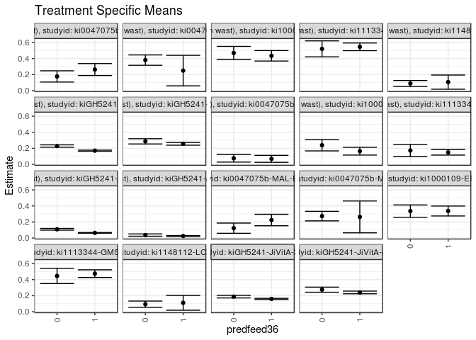

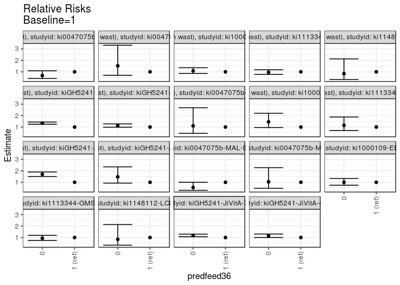

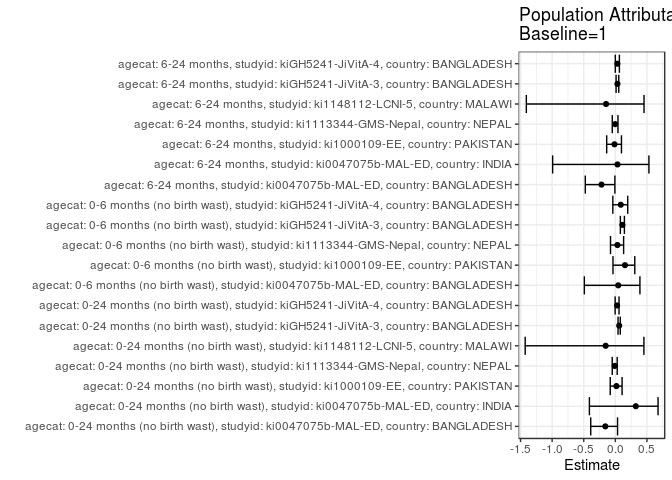

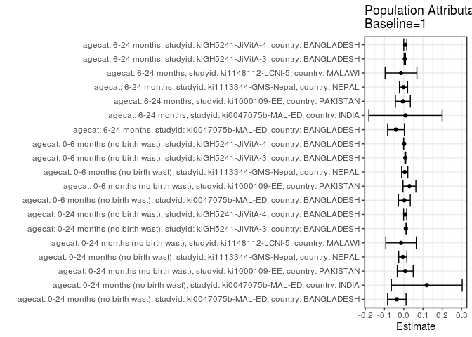

## Results Table

### Parameter: TSM

| agecat | studyid | country | intervention_level | baseline_level | estimate | ci_lower | ci_upper |
| --- | --- | --- | --- | --- | --- | --- | --- |
| 0-24 months (no birth wast) | ki0047075b-MAL-ED | BANGLADESH | 1 | NA | 0.2629779 | 0.1884901 | 0.3374657 |
| 0-24 months (no birth wast) | ki0047075b-MAL-ED | BANGLADESH | 0 | NA | 0.1772053 | 0.1071890 | 0.2472217 |
| 0-24 months (no birth wast) | ki0047075b-MAL-ED | INDIA | 1 | NA | 0.2500000 | 0.0598274 | 0.4401726 |
| 0-24 months (no birth wast) | ki0047075b-MAL-ED | INDIA | 0 | NA | 0.3807339 | 0.3161412 | 0.4453267 |
| 0-24 months (no birth wast) | ki1000109-EE | PAKISTAN | 1 | NA | 0.4343384 | 0.3689931 | 0.4996837 |
| 0-24 months (no birth wast) | ki1000109-EE | PAKISTAN | 0 | NA | 0.4692538 | 0.3870960 | 0.5514117 |
| 0-24 months (no birth wast) | ki1113344-GMS-Nepal | NEPAL | 1 | NA | 0.5463566 | 0.4984866 | 0.5942266 |
| 0-24 months (no birth wast) | ki1113344-GMS-Nepal | NEPAL | 0 | NA | 0.5207363 | 0.4212486 | 0.6202240 |
| 0-24 months (no birth wast) | ki1148112-LCNI-5 | MALAWI | 1 | NA | 0.1063830 | 0.0180722 | 0.1946938 |
| 0-24 months (no birth wast) | ki1148112-LCNI-5 | MALAWI | 0 | NA | 0.0892857 | 0.0518739 | 0.1266975 |
| 0-24 months (no birth wast) | kiGH5241-JiVitA-3 | BANGLADESH | 1 | NA | 0.1704731 | 0.1638033 | 0.1771429 |
| 0-24 months (no birth wast) | kiGH5241-JiVitA-3 | BANGLADESH | 0 | NA | 0.2279675 | 0.2129184 | 0.2430166 |
| 0-24 months (no birth wast) | kiGH5241-JiVitA-4 | BANGLADESH | 1 | NA | 0.2560125 | 0.2389552 | 0.2730697 |
| 0-24 months (no birth wast) | kiGH5241-JiVitA-4 | BANGLADESH | 0 | NA | 0.2866749 | 0.2537828 | 0.3195670 |
| 0-6 months (no birth wast) | ki0047075b-MAL-ED | BANGLADESH | 1 | NA | 0.0687023 | 0.0253000 | 0.1121046 |
| 0-6 months (no birth wast) | ki0047075b-MAL-ED | BANGLADESH | 0 | NA | 0.0756303 | 0.0280293 | 0.1232312 |
| 0-6 months (no birth wast) | ki1000109-EE | PAKISTAN | 1 | NA | 0.1639509 | 0.1156245 | 0.2122773 |
| 0-6 months (no birth wast) | ki1000109-EE | PAKISTAN | 0 | NA | 0.2385198 | 0.1677107 | 0.3093289 |
| 0-6 months (no birth wast) | ki1113344-GMS-Nepal | NEPAL | 1 | NA | 0.1502648 | 0.1154880 | 0.1850416 |
| 0-6 months (no birth wast) | ki1113344-GMS-Nepal | NEPAL | 0 | NA | 0.1723935 | 0.0973322 | 0.2474548 |
| 0-6 months (no birth wast) | kiGH5241-JiVitA-3 | BANGLADESH | 1 | NA | 0.0645117 | 0.0601848 | 0.0688386 |
| 0-6 months (no birth wast) | kiGH5241-JiVitA-3 | BANGLADESH | 0 | NA | 0.1090492 | 0.0982236 | 0.1198748 |
| 0-6 months (no birth wast) | kiGH5241-JiVitA-4 | BANGLADESH | 1 | NA | 0.0251120 | 0.0191932 | 0.0310308 |
| 0-6 months (no birth wast) | kiGH5241-JiVitA-4 | BANGLADESH | 0 | NA | 0.0370181 | 0.0226925 | 0.0513437 |
| 6-24 months | ki0047075b-MAL-ED | BANGLADESH | 1 | NA | 0.2244124 | 0.1529267 | 0.2958982 |
| 6-24 months | ki0047075b-MAL-ED | BANGLADESH | 0 | NA | 0.1227822 | 0.0590689 | 0.1864955 |
| 6-24 months | ki0047075b-MAL-ED | INDIA | 1 | NA | 0.2631579 | 0.0647346 | 0.4615812 |
| 6-24 months | ki0047075b-MAL-ED | INDIA | 0 | NA | 0.2731481 | 0.2135999 | 0.3326964 |
| 6-24 months | ki1000109-EE | PAKISTAN | 1 | NA | 0.3368565 | 0.2750115 | 0.3987015 |
| 6-24 months | ki1000109-EE | PAKISTAN | 0 | NA | 0.3358410 | 0.2591835 | 0.4124984 |
| 6-24 months | ki1113344-GMS-Nepal | NEPAL | 1 | NA | 0.4745798 | 0.4269189 | 0.5222407 |
| 6-24 months | ki1113344-GMS-Nepal | NEPAL | 0 | NA | 0.4460696 | 0.3512108 | 0.5409284 |
| 6-24 months | ki1148112-LCNI-5 | MALAWI | 1 | NA | 0.1111111 | 0.0191112 | 0.2031111 |
| 6-24 months | ki1148112-LCNI-5 | MALAWI | 0 | NA | 0.0938967 | 0.0546489 | 0.1331445 |
| 6-24 months | kiGH5241-JiVitA-3 | BANGLADESH | 1 | NA | 0.1597674 | 0.1522608 | 0.1672741 |
| 6-24 months | kiGH5241-JiVitA-3 | BANGLADESH | 0 | NA | 0.1881630 | 0.1719411 | 0.2043849 |
| 6-24 months | kiGH5241-JiVitA-4 | BANGLADESH | 1 | NA | 0.2404708 | 0.2236016 | 0.2573400 |
| 6-24 months | kiGH5241-JiVitA-4 | BANGLADESH | 0 | NA | 0.2747782 | 0.2430266 | 0.3065298 |

### Parameter: E(Y)

| agecat | studyid | country | intervention_level | baseline_level | estimate | ci_lower | ci_upper |
| --- | --- | --- | --- | --- | --- | --- | --- |
| 0-24 months (no birth wast) | ki0047075b-MAL-ED | BANGLADESH | NA | NA | 0.2270916 | 0.1751587 | 0.2790245 |
| 0-24 months (no birth wast) | ki0047075b-MAL-ED | INDIA | NA | NA | 0.3697479 | 0.3082891 | 0.4312067 |
| 0-24 months (no birth wast) | ki1000109-EE | PAKISTAN | NA | NA | 0.4420485 | 0.3914450 | 0.4926520 |
| 0-24 months (no birth wast) | ki1113344-GMS-Nepal | NEPAL | NA | NA | 0.5414258 | 0.4985159 | 0.5843357 |
| 0-24 months (no birth wast) | ki1148112-LCNI-5 | MALAWI | NA | NA | 0.0922509 | 0.0577338 | 0.1267680 |
| 0-24 months (no birth wast) | kiGH5241-JiVitA-3 | BANGLADESH | NA | NA | 0.1815052 | 0.1751641 | 0.1878464 |
| 0-24 months (no birth wast) | kiGH5241-JiVitA-4 | BANGLADESH | NA | NA | 0.2634136 | 0.2482170 | 0.2786101 |
| 0-6 months (no birth wast) | ki0047075b-MAL-ED | BANGLADESH | NA | NA | 0.0720000 | 0.0398938 | 0.1041062 |
| 0-6 months (no birth wast) | ki1000109-EE | PAKISTAN | NA | NA | 0.1934605 | 0.1529920 | 0.2339289 |
| 0-6 months (no birth wast) | ki1113344-GMS-Nepal | NEPAL | NA | NA | 0.1553785 | 0.1236568 | 0.1871001 |
| 0-6 months (no birth wast) | kiGH5241-JiVitA-3 | BANGLADESH | NA | NA | 0.0726480 | 0.0685748 | 0.0767212 |
| 0-6 months (no birth wast) | kiGH5241-JiVitA-4 | BANGLADESH | NA | NA | 0.0274651 | 0.0220747 | 0.0328555 |
| 6-24 months | ki0047075b-MAL-ED | BANGLADESH | NA | NA | 0.1841004 | 0.1348619 | 0.2333390 |
| 6-24 months | ki0047075b-MAL-ED | INDIA | NA | NA | 0.2723404 | 0.2153029 | 0.3293779 |
| 6-24 months | ki1000109-EE | PAKISTAN | NA | NA | 0.3324324 | 0.2843668 | 0.3804980 |
| 6-24 months | ki1113344-GMS-Nepal | NEPAL | NA | NA | 0.4733840 | 0.4306748 | 0.5160933 |
| 6-24 months | ki1148112-LCNI-5 | MALAWI | NA | NA | 0.0968992 | 0.0607324 | 0.1330660 |
| 6-24 months | kiGH5241-JiVitA-3 | BANGLADESH | NA | NA | 0.1652718 | 0.1582686 | 0.1722751 |
| 6-24 months | kiGH5241-JiVitA-4 | BANGLADESH | NA | NA | 0.2485155 | 0.2334424 | 0.2635886 |

### Parameter: RR

| agecat | studyid | country | intervention_level | baseline_level | estimate | ci_lower | ci_upper |
| --- | --- | --- | --- | --- | --- | --- | --- |
| 0-24 months (no birth wast) | ki0047075b-MAL-ED | BANGLADESH | 1 | 1 | 1.0000000 | 1.0000000 | 1.000000 |
| 0-24 months (no birth wast) | ki0047075b-MAL-ED | BANGLADESH | 0 | 1 | 0.6738412 | 0.4164580 | 1.090295 |
| 0-24 months (no birth wast) | ki0047075b-MAL-ED | INDIA | 1 | 1 | 1.0000000 | 1.0000000 | 1.000000 |
| 0-24 months (no birth wast) | ki0047075b-MAL-ED | INDIA | 0 | 1 | 1.5229358 | 0.6985563 | 3.320181 |
| 0-24 months (no birth wast) | ki1000109-EE | PAKISTAN | 1 | 1 | 1.0000000 | 1.0000000 | 1.000000 |
| 0-24 months (no birth wast) | ki1000109-EE | PAKISTAN | 0 | 1 | 1.0803876 | 0.8594519 | 1.358118 |
| 0-24 months (no birth wast) | ki1113344-GMS-Nepal | NEPAL | 1 | 1 | 1.0000000 | 1.0000000 | 1.000000 |
| 0-24 months (no birth wast) | ki1113344-GMS-Nepal | NEPAL | 0 | 1 | 0.9531070 | 0.7723987 | 1.176093 |
| 0-24 months (no birth wast) | ki1148112-LCNI-5 | MALAWI | 1 | 1 | 1.0000000 | 1.0000000 | 1.000000 |
| 0-24 months (no birth wast) | ki1148112-LCNI-5 | MALAWI | 0 | 1 | 0.8392857 | 0.3311837 | 2.126918 |
| 0-24 months (no birth wast) | kiGH5241-JiVitA-3 | BANGLADESH | 1 | 1 | 1.0000000 | 1.0000000 | 1.000000 |
| 0-24 months (no birth wast) | kiGH5241-JiVitA-3 | BANGLADESH | 0 | 1 | 1.3372637 | 1.2436613 | 1.437911 |
| 0-24 months (no birth wast) | kiGH5241-JiVitA-4 | BANGLADESH | 1 | 1 | 1.0000000 | 1.0000000 | 1.000000 |
| 0-24 months (no birth wast) | kiGH5241-JiVitA-4 | BANGLADESH | 0 | 1 | 1.1197692 | 0.9818321 | 1.277085 |
| 0-6 months (no birth wast) | ki0047075b-MAL-ED | BANGLADESH | 1 | 1 | 1.0000000 | 1.0000000 | 1.000000 |
| 0-6 months (no birth wast) | ki0047075b-MAL-ED | BANGLADESH | 0 | 1 | 1.1008403 | 0.4512722 | 2.685407 |
| 0-6 months (no birth wast) | ki1000109-EE | PAKISTAN | 1 | 1 | 1.0000000 | 1.0000000 | 1.000000 |
| 0-6 months (no birth wast) | ki1000109-EE | PAKISTAN | 0 | 1 | 1.4548245 | 0.9583199 | 2.208568 |
| 0-6 months (no birth wast) | ki1113344-GMS-Nepal | NEPAL | 1 | 1 | 1.0000000 | 1.0000000 | 1.000000 |
| 0-6 months (no birth wast) | ki1113344-GMS-Nepal | NEPAL | 0 | 1 | 1.1472650 | 0.7008192 | 1.878112 |
| 0-6 months (no birth wast) | kiGH5241-JiVitA-3 | BANGLADESH | 1 | 1 | 1.0000000 | 1.0000000 | 1.000000 |
| 0-6 months (no birth wast) | kiGH5241-JiVitA-3 | BANGLADESH | 0 | 1 | 1.6903782 | 1.5008245 | 1.903873 |
| 0-6 months (no birth wast) | kiGH5241-JiVitA-4 | BANGLADESH | 1 | 1 | 1.0000000 | 1.0000000 | 1.000000 |
| 0-6 months (no birth wast) | kiGH5241-JiVitA-4 | BANGLADESH | 0 | 1 | 1.4741210 | 0.9252150 | 2.348679 |
| 6-24 months | ki0047075b-MAL-ED | BANGLADESH | 1 | 1 | 1.0000000 | 1.0000000 | 1.000000 |
| 6-24 months | ki0047075b-MAL-ED | BANGLADESH | 0 | 1 | 0.5471276 | 0.2991190 | 1.000767 |
| 6-24 months | ki0047075b-MAL-ED | INDIA | 1 | 1 | 1.0000000 | 1.0000000 | 1.000000 |
| 6-24 months | ki0047075b-MAL-ED | INDIA | 0 | 1 | 1.0379630 | 0.4734863 | 2.275393 |
| 6-24 months | ki1000109-EE | PAKISTAN | 1 | 1 | 1.0000000 | 1.0000000 | 1.000000 |
| 6-24 months | ki1000109-EE | PAKISTAN | 0 | 1 | 0.9969852 | 0.7443344 | 1.335394 |
| 6-24 months | ki1113344-GMS-Nepal | NEPAL | 1 | 1 | 1.0000000 | 1.0000000 | 1.000000 |
| 6-24 months | ki1113344-GMS-Nepal | NEPAL | 0 | 1 | 0.9399254 | 0.7430569 | 1.188953 |
| 6-24 months | ki1148112-LCNI-5 | MALAWI | 1 | 1 | 1.0000000 | 1.0000000 | 1.000000 |
| 6-24 months | ki1148112-LCNI-5 | MALAWI | 0 | 1 | 0.8450704 | 0.3342527 | 2.136539 |
| 6-24 months | kiGH5241-JiVitA-3 | BANGLADESH | 1 | 1 | 1.0000000 | 1.0000000 | 1.000000 |
| 6-24 months | kiGH5241-JiVitA-3 | BANGLADESH | 0 | 1 | 1.1777306 | 1.0713932 | 1.294622 |
| 6-24 months | kiGH5241-JiVitA-4 | BANGLADESH | 1 | 1 | 1.0000000 | 1.0000000 | 1.000000 |
| 6-24 months | kiGH5241-JiVitA-4 | BANGLADESH | 0 | 1 | 1.1426677 | 1.0001905 | 1.305441 |

### Parameter: PAR

| agecat | studyid | country | intervention_level | baseline_level | estimate | ci_lower | ci_upper |
| --- | --- | --- | --- | --- | --- | --- | --- |
| 0-24 months (no birth wast) | ki0047075b-MAL-ED | BANGLADESH | 1 | NA | -0.0358863 | -0.0839783 | 0.0122058 |
| 0-24 months (no birth wast) | ki0047075b-MAL-ED | INDIA | 1 | NA | 0.1197479 | -0.0642754 | 0.3037711 |
| 0-24 months (no birth wast) | ki1000109-EE | PAKISTAN | 1 | NA | 0.0077101 | -0.0336327 | 0.0490529 |
| 0-24 months (no birth wast) | ki1113344-GMS-Nepal | NEPAL | 1 | NA | -0.0049308 | -0.0261698 | 0.0163082 |
| 0-24 months (no birth wast) | ki1148112-LCNI-5 | MALAWI | 1 | NA | -0.0141321 | -0.0934107 | 0.0651466 |
| 0-24 months (no birth wast) | kiGH5241-JiVitA-3 | BANGLADESH | 1 | NA | 0.0110321 | 0.0077773 | 0.0142869 |
| 0-24 months (no birth wast) | kiGH5241-JiVitA-4 | BANGLADESH | 1 | NA | 0.0074011 | -0.0006950 | 0.0154972 |
| 0-6 months (no birth wast) | ki0047075b-MAL-ED | BANGLADESH | 1 | NA | 0.0032977 | -0.0273680 | 0.0339634 |
| 0-6 months (no birth wast) | ki1000109-EE | PAKISTAN | 1 | NA | 0.0295096 | -0.0040378 | 0.0630570 |
| 0-6 months (no birth wast) | ki1113344-GMS-Nepal | NEPAL | 1 | NA | 0.0051137 | -0.0109976 | 0.0212250 |
| 0-6 months (no birth wast) | kiGH5241-JiVitA-3 | BANGLADESH | 1 | NA | 0.0081363 | 0.0057817 | 0.0104908 |
| 0-6 months (no birth wast) | kiGH5241-JiVitA-4 | BANGLADESH | 1 | NA | 0.0023531 | -0.0009006 | 0.0056068 |
| 6-24 months | ki0047075b-MAL-ED | BANGLADESH | 1 | NA | -0.0403120 | -0.0838044 | 0.0031804 |
| 6-24 months | ki0047075b-MAL-ED | INDIA | 1 | NA | 0.0091825 | -0.1812343 | 0.1995994 |
| 6-24 months | ki1000109-EE | PAKISTAN | 1 | NA | -0.0044241 | -0.0432141 | 0.0343660 |
| 6-24 months | ki1113344-GMS-Nepal | NEPAL | 1 | NA | -0.0011958 | -0.0224755 | 0.0200840 |
| 6-24 months | ki1148112-LCNI-5 | MALAWI | 1 | NA | -0.0142119 | -0.0967920 | 0.0683682 |
| 6-24 months | kiGH5241-JiVitA-3 | BANGLADESH | 1 | NA | 0.0055044 | 0.0019903 | 0.0090184 |
| 6-24 months | kiGH5241-JiVitA-4 | BANGLADESH | 1 | NA | 0.0080447 | 0.0000699 | 0.0160196 |

### Parameter: PAF

| agecat | studyid | country | intervention_level | baseline_level | estimate | ci_lower | ci_upper |
| --- | --- | --- | --- | --- | --- | --- | --- |
| 0-24 months (no birth wast) | ki0047075b-MAL-ED | BANGLADESH | 1 | NA | -0.1580255 | -0.3894219 | 0.0348339 |
| 0-24 months (no birth wast) | ki0047075b-MAL-ED | INDIA | 1 | NA | 0.3238636 | -0.4103559 | 0.6758546 |
| 0-24 months (no birth wast) | ki1000109-EE | PAKISTAN | 1 | NA | 0.0174418 | -0.0807030 | 0.1066734 |
| 0-24 months (no birth wast) | ki1113344-GMS-Nepal | NEPAL | 1 | NA | -0.0091070 | -0.0491146 | 0.0293748 |
| 0-24 months (no birth wast) | ki1148112-LCNI-5 | MALAWI | 1 | NA | -0.1531915 | -1.4265796 | 0.4519650 |
| 0-24 months (no birth wast) | kiGH5241-JiVitA-3 | BANGLADESH | 1 | NA | 0.0607813 | 0.0428810 | 0.0783468 |
| 0-24 months (no birth wast) | kiGH5241-JiVitA-4 | BANGLADESH | 1 | NA | 0.0280969 | -0.0031361 | 0.0583574 |
| 0-6 months (no birth wast) | ki0047075b-MAL-ED | BANGLADESH | 1 | NA | 0.0458015 | -0.4903867 | 0.3890883 |
| 0-6 months (no birth wast) | ki1000109-EE | PAKISTAN | 1 | NA | 0.1525354 | -0.0373100 | 0.3076359 |
| 0-6 months (no birth wast) | ki1113344-GMS-Nepal | NEPAL | 1 | NA | 0.0329113 | -0.0763716 | 0.1310987 |
| 0-6 months (no birth wast) | kiGH5241-JiVitA-3 | BANGLADESH | 1 | NA | 0.1119960 | 0.0795190 | 0.1433272 |
| 0-6 months (no birth wast) | kiGH5241-JiVitA-4 | BANGLADESH | 1 | NA | 0.0856771 | -0.0396443 | 0.1958920 |
| 6-24 months | ki0047075b-MAL-ED | BANGLADESH | 1 | NA | -0.2189675 | -0.4752585 | -0.0072009 |
| 6-24 months | ki0047075b-MAL-ED | INDIA | 1 | NA | 0.0337171 | -0.9922711 | 0.5313376 |
| 6-24 months | ki1000109-EE | PAKISTAN | 1 | NA | -0.0133082 | -0.1369896 | 0.0969192 |
| 6-24 months | ki1113344-GMS-Nepal | NEPAL | 1 | NA | -0.0025260 | -0.0485027 | 0.0414346 |
| 6-24 months | ki1148112-LCNI-5 | MALAWI | 1 | NA | -0.1466667 | -1.4083049 | 0.4540374 |
| 6-24 months | kiGH5241-JiVitA-3 | BANGLADESH | 1 | NA | 0.0333049 | 0.0119073 | 0.0542392 |
| 6-24 months | kiGH5241-JiVitA-4 | BANGLADESH | 1 | NA | 0.0323712 | -0.0002662 | 0.0639437 |